# DS 202 Final Project

Kellan Bouwman, Adam Ford, Heather Moore, Brett White, Ashley Sackpraseuth, Felix Baez

## Voter Participation Analysis by Congression District for the 2018 Midterm Election

**Overview**

The data used in this project was collected for the 2018 US midterm elections. The data came from the Census Bureau website in the form of five Excel spreadsheets. These spreadsheets contain information about the voting populations in each congressional district as well as age, education, sex, race, and poverty status information about the voters. The purpose of our analysis is to find strong correlations between voter participation and voter demographics. One important thing to note about midterm elections is that they tend to have much lower voter turnout than presidential elections.

# Introduction & Cleaning

The data was contained in five Excel spreadsheets. These spreadsheets were formatted so that they were easy for a human to read, but they were not formatted well for R. Each spreadsheet was converted to a csv file by simply saving the spreadsheet as a csv file in Excel. Once this was done, the new csv files were opened in Excel and further cleaned.

The columns in the spreadsheet were actually separated into two rows: a main column and then multiple subcolumns for each main column. The subcolumns were renamed so that they reflected which main column they belonged to. Once all of the subcolumns were renamed, any main column that did not have any subcolumns had its name put in the subcolumn row and then the main column name row was deleted. In addition, any other rows that contained other non-tabular information were deleted.

Next, the population and votes cast columns were adjusted so that the numbers were integers (no decimal) without commas. Missing values were replaced with NA so that R would read them as missing instead of as a character vector. In addition, there were a few columns which contained specific values for missing data such as a dash or the letter N. There were also replaced with NA so that R would read them as missing instead of as a character vector.

Overall, there were only five congressional districts in the general voter data table that were missing values. The tables which broke voters down by race had many missing values because some races had so little members in a district that the count was not recorded. These “missing” races were treated as missing values during cleaning to preserve this meaning, but during analysis they were treated as 0.

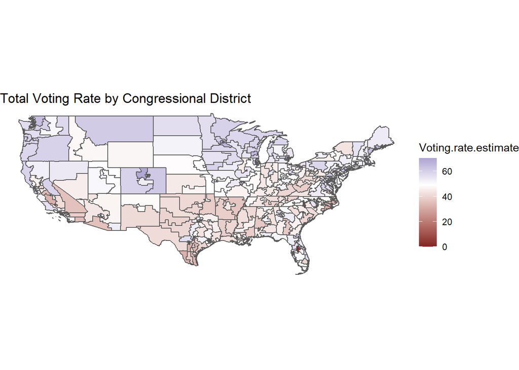

This map shows the voting rates for each congressional district. The general tendency is that districts in the north tend to have higher voter turnout than those in the south.

# Education Analysis

This gives us the national average for highest level of education. This is nice to see for when we are looking at comparison graphs to see how the national average compares to the correlation graph.

```
## # A tibble: 7 x 2
##   Education                        mean
##   <chr>                           <dbl>
## 1 Associate.degree.estimate        8.52
## 2 Bachelor.degree.estimate        19.2
## 3 Grade.9.12.no.diploma.estimate   6.84
## 4 Graduate.degree.estimate        11.2
## 5 High.school.graduate.estimate   27.8
## 6 Less.grade.9.estimate            3.16
## 7 Some.college.no.degree.estimate 23.3
```

While the table above gives us the national averages for highest level of education, we should also look more broad categories such on average in a district how many people have a high school diploma or more education as well as who has at least a bachelors degree or more.

The national average for those who have at least Highschool level education or more is 90%, and the national average per congressional district the percent of people who have at least a bachelors degree is 30.37%. Finally the national average voting rate per district is 49.16%.

Below are graphs of voter participation by percentage of a district with a certain education level. This shows us that the higher percentage of your population with a high level of education the voter participation increases. So as the lower highest level of education decreases, the voter participation increases.

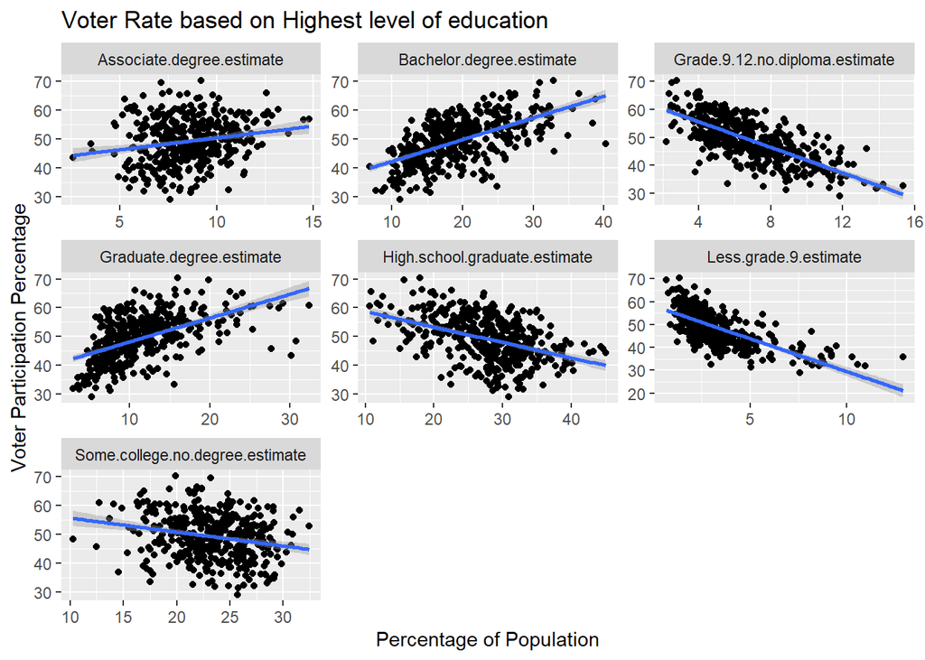

With the knowledge that as a higher percentage of a district is educated I looked at the more general categories to see the voting trends. So I compared the district to the national average for a district for at least high school level education obtained and the effect on voter participation. As expected as the rate is above the national average there is an increase in voter participation, and when is it lower there is a lower voting participation. There is a clustering of data near the 0 - 5 percent difference, for at least high school education. There are two possible reasons for this, the primary being a ceiling effect at 100%, since the national average is 90.004%, the second is that since the value is so large there are other factors playing a role in voter participation. The affect of these factors led me to look at people with at least a bachelors degrees.

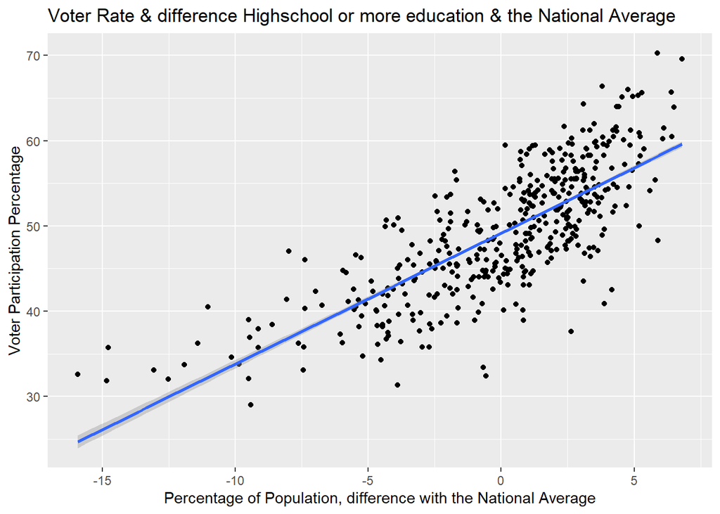

Then I used a similar graph as the difference of the national average of high school with the bachelor degree difference with the national average for bachelor degree’s per district. The national average for this is 30.37% which could present a floor effect at 0, but thankfully we do not have any such outliers. Instead even with some percentages being lower than the national average, we start to see a more spread out, consistent and better predictor of voter participation. This also further proves the assumption earlier that the higher percent of a district population with higher levels of education.

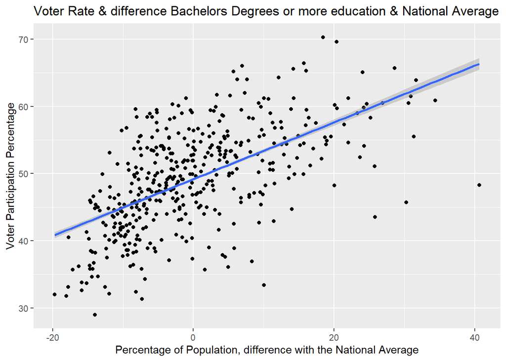

# Age Analysis

### 18 - 29

```
##   stateName congressDist dif18.29 votingRate
## 1   Florida           11 8.736468       56.4
## 2   Florida           17 8.136468       50.5
## 3   Florida           19 8.036468       53.8
## 4   Florida           12 7.636468       55.3
## 5   Florida           16 7.136468       56.7
```

### 30 - 44

```
##   stateName congressDist dif30.44 votingRate
## 1   Florida           11 8.958028       56.4
## 2   Florida           19 8.158028       53.8
## 3   Florida           17 7.358028       50.5
## 4   Florida           21 5.558028         NA
## 5  New York            3 5.558028       52.4
```

### 45 - 64

```
##              stateName congressDist dif45.64 votingRate
## 1             New York           12 9.557569       48.3
## 2        Massachusetts            7 9.057569       44.7
## 3 District of Columbia     At-large 8.257569       43.5
## 4           California           40 7.857569       35.7
## 5           California           34 7.657569       35.7
```

### 65 and up

```
##        stateName congressDist dif65.up votingRate
## 1        Arizona            7 9.651835       29.0
## 2          Texas           29 8.751835       31.8
## 3     California           41 7.951835       34.7
## 4     California           35 7.751835       33.1
## 5 North Carolina           12 7.551835       47.2
```

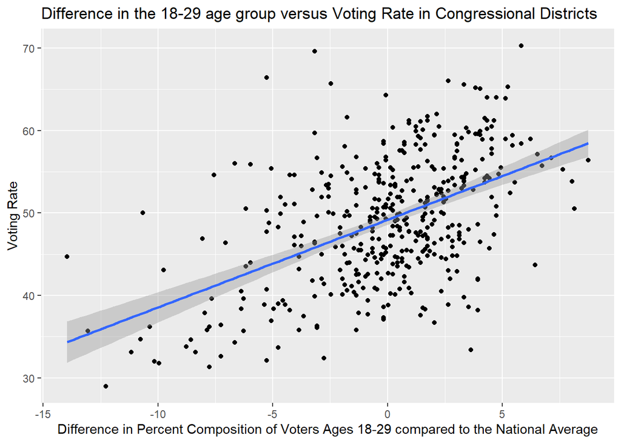

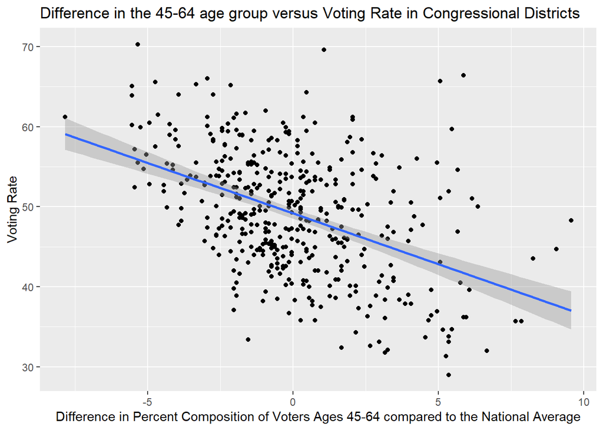

These two graphs show two starkly different relationships between Difference of Composition of Voters Ages 18-29 and 45-64 versus the respective Voting Rates. In more layman’s terms, congressional districts that has a higher percentage of voters 18-29 than the national average, tend to have better voter turnouts. The opposite can be said about the age group of 45-64. Therefore, we can conclude that citizens 18-29 are the group that has the greatest influence on increasing the voting rate.

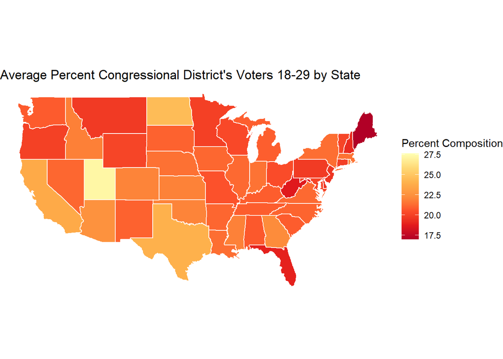

# Geographic Analysis

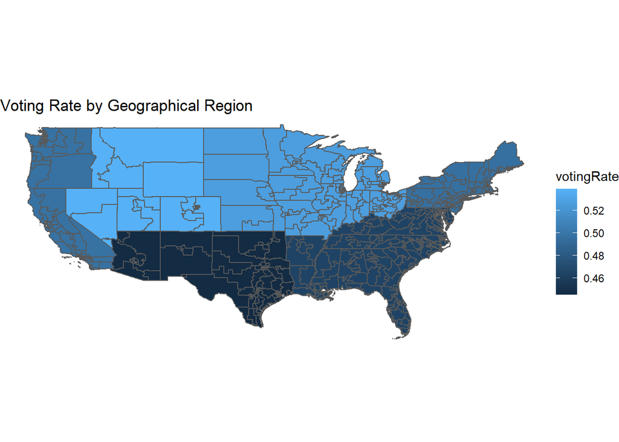

The total voting rate map by US region compares what regions have more or less voter turnout. According to the displayed map, we can see that the region with the least voter turnout is that of the Southwest. Surprisingly, the region with the most voter turnout is that of the Rocky Mountains. One possible reason for this, is that the Rocky Mountains region has many different names and changes depending on who you ask. Sometimes it is added together with the Pacific states to form the “West” region of the US. We can also see that here in the Midwest the voter turnout is relatively high which took me by surprise. One potential reason for this is that the midwest is a well known “battleground” region with states such as Wisconsin, Michigan and Iowa being decisive in many elections. The turnout probably reflects the “heavy” campaigning done by politicians when trying to sway the election to their favor in these states.

# Race Analysis

```
## # A tibble: 5 x 2
##   Race.ethnicity           mean
##   <fct>                   <dbl>
## 1 White.voting.rate        75.5
## 2 Hispanic.voting.rate     13.7
## 3 Black.voting.rate        12.9
## 4 Asian.voting.rate         4.6
## 5 Two.or.more.voting.rate   2.5
```

Before looking at the geographical distribution of voting partipcation by race, this table gives a brief introduction as to what to expect. White voters have the highest voting participation rate by far, making up, on average, 75.5% of a congressional district’s total voting rate. This voting participation rate is then followed by Hispanic, Black, Asian, and Multiracial voters.

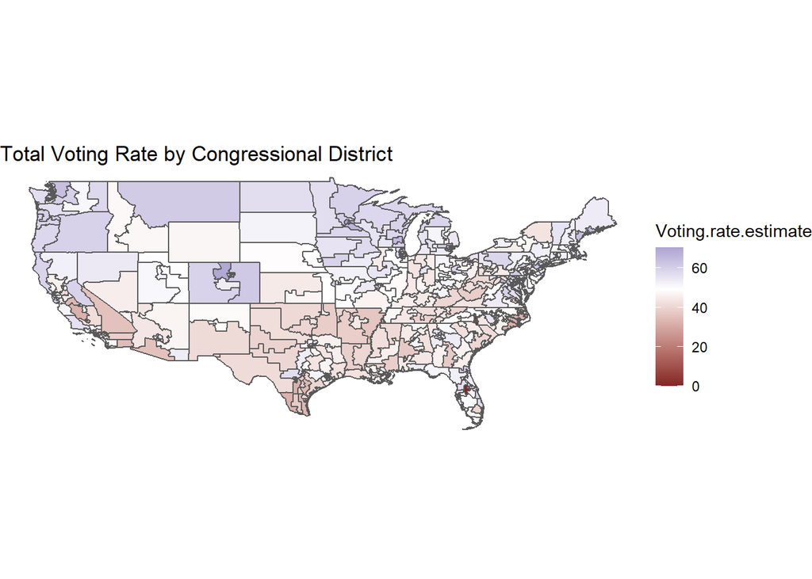

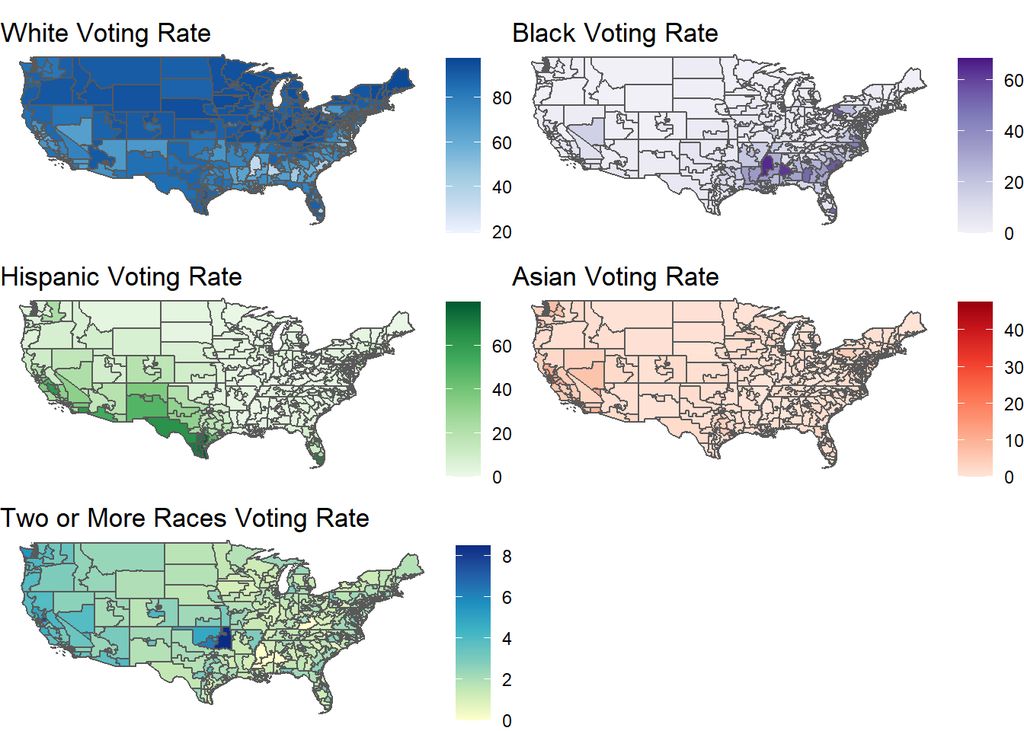

The Total Voting Rate by Congressional District map shows that the states in the northern half of the U.S. have above average voting turnout rates whereas the states in the southern half of the U.S. have below average voting turnout rates. The Total Voting Rate by Congressional District map looks very similar to the White Voting Rate map. The one area of the White Voting Rate map that has low voting rates (southeast corner of the U.S.), is the one area of the map where Black Voting Rates are very high. We are also seeing that Hispanic Voting Rates are highest in the southwest corner of the U.S. Asian Voting Rates are low across the map. Two or More Races Voting Rates are highest in Oklahoma and the west coast of the U.S. Overall, these maps tell us that Whites have a strong influence on overall voting rates. The areas with the highest total voting rates had the highest White voting rates and the areas that had below average voting rates were the areas with the low White voting rates but high minority voting participation rates.

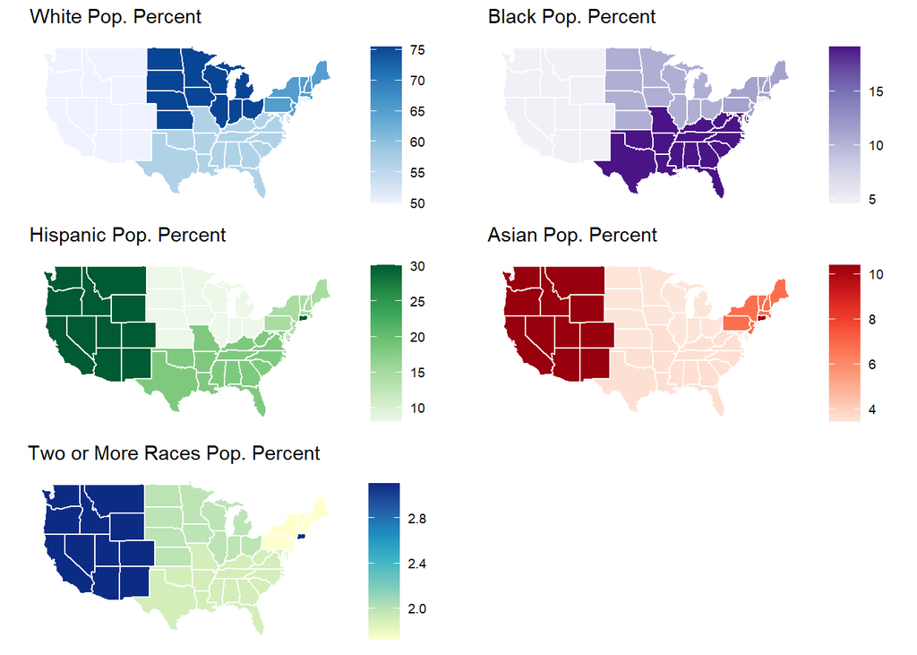

When comparing the geographical distribution of voters to the geographical distribution of citizens, few maps exhibit similar trends. Both the Black Population Percentage and Two or More Races Population Percentage map display the same trends seen in their voting rap maps, but does not hold true for the other three races analyzed. In both the Hispanic and Asian Population Percentage maps, we are seeing a high percentage of citizens in the west, but do not see their presence in their voting rate maps. This tells us that Hispanic and Asian citizens are not showing up to vote, especially on the west coast. The White Voting Rate makes it seem like there are more White citizens in the northern half of the U.S., but the Census data says otherwise. Because we are seeing a higher percentage of White presence in the Voting Rate map than the Population Percentage, we can conclude that White voters are the best at showing up to vote.

# Poverty Analysis

```
##            region Congressional.district Below.poverty.level.percent.total
## 1        new york                     15                              30.0
## 2        michigan                     13                              24.7
## 3        kentucky                      5                              24.0
## 4        new york                     13                              22.1
## 5    pennsylvania                      2                              21.6
## 6         alabama                      7                              21.5
## 7         georgia                      2                              21.2
## 8            ohio                     11                              21.1
## 9    pennsylvania                      3                              21.1
## 10      tennessee                      9                              21.0
## 11    mississippi                      2                              20.4
## 12 south carolina                      6                              20.3
## 13     california                     16                              20.2
## 14      louisiana                      5                              20.2
```

The table above displays the congressional districts that have the highest percentage of voters under the poverty line. It appears the New York’s 15th Congressional district has the most below poverty line voters at 30%. Following behind is Michigan’s 13th and Kentucky’s 5th districts at 24%. It’s important to note that out of the top ten, four of the states are in the southern part of the United States. Also, both New York and Pennsylvania have 2 districts that fall under this classification.

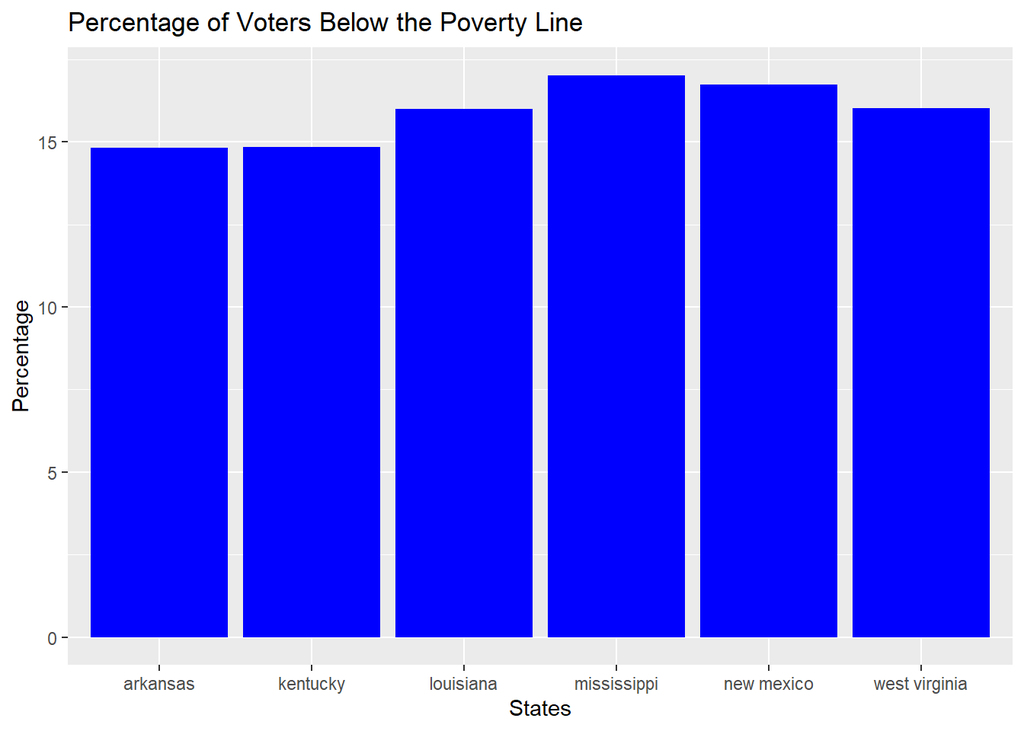

After completing some analysis on the individual congressional districts, it will be meaningful to see if the same results would stand when looking at the states as a whole. The bar graph displays the states with the largest percentage of voters below the poverty line. In contrast from the table above, Mississippi has the most below poverty line voters at almost 17% of voters participation falling into that category. An important pattern that is developing is that southern states tend to have the most voters that fall below the poverty line.

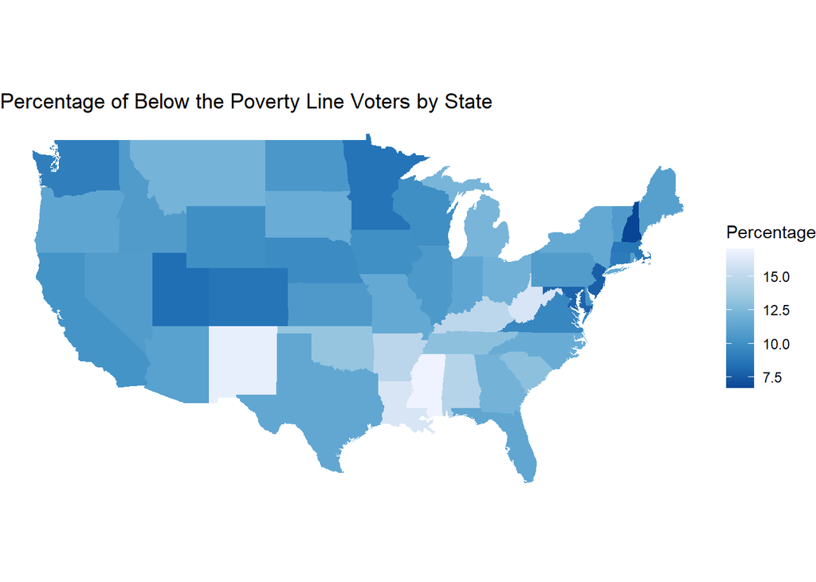

The final part of this analysis shows the correlation of below poverty line voters and the states. In this map, the south holds the largest group of below poverty line voters. Which continues to proves the pattern that the south has most of the voters in that category.

# **Conclusion**

## Key Take Aways

1. Increasing education, specifically at the bachelor degree level is fastest way to increase voter participation from an education stand point.
2. Voter’s 18-29 have the greatest impact on the overall turnout of their district, meaning it is most important to ensure that group is voting at all elections.
3. The Midwest region has a high voter turnout rate due to the “battleground” nature of many of the states.
4. White voters have the highest voting participation rate.
5. Southern states have some of the highest turnout for voters who fall below the poverty line.

## Work Contributions

- Kellan Bouwman: Project Coordinator, I helped with creating a platform for communication and clarifying overall questions about our project. I also did the overall set up of the document (initially), and created planning documents to help project facilitation. I did all of the exploratory analysis, for education and voter participation. I also created the project overview, conclusion and key take away area of the paper.
- Adam Ford: I worked primarily on the Age analysis and exploration. I aided in completing the conclusions, key takeaways and overall document formatting.
- Brett White: I cleaned the original Excel sheets into a more usable csv format. This involved creating subcolumns, renaming them, and handling missing data in a proper manner. I also wrote about this process in the report. Additionally, I helped teammates to map via Congressional districts, outside the standard methods taught in class.
- Felix Baez: I performed the exploration on Geographic trends section. Additionally, I added relevant conclusions and take aways to the report.
- Ashley Sackpraseuth: My primary section was Race Analysis, but I also created the graph of voter participation to be used in the introduction. I also added new datasets to the repository to create more meaningful graphs. I added to the conclusions for my sections as well.
- Heather Moore: My focus was on the Poverty Analysis section of the report. I contributed to the conclusion and key take aways additionally.